# PA_Template1

Zack Gouttel

15/06/2020

# Assignment Report

This is an R Markdown made docment for the Assignment report of Reproducible Research’s 1st Course Project

# 1.Reading the data into R

I used read.csv:

```r
activity <- read.csv("~/GitHub/RR_CP1/repdata_data_activity/activity.csv")
```

# 2.a Calculating the total number of steps per day and plotting it

Did this through the aggregate function

```r
sum_steps<- aggregate(activity[, 1], list(activity$date), sum, na.rm=TRUE)
```

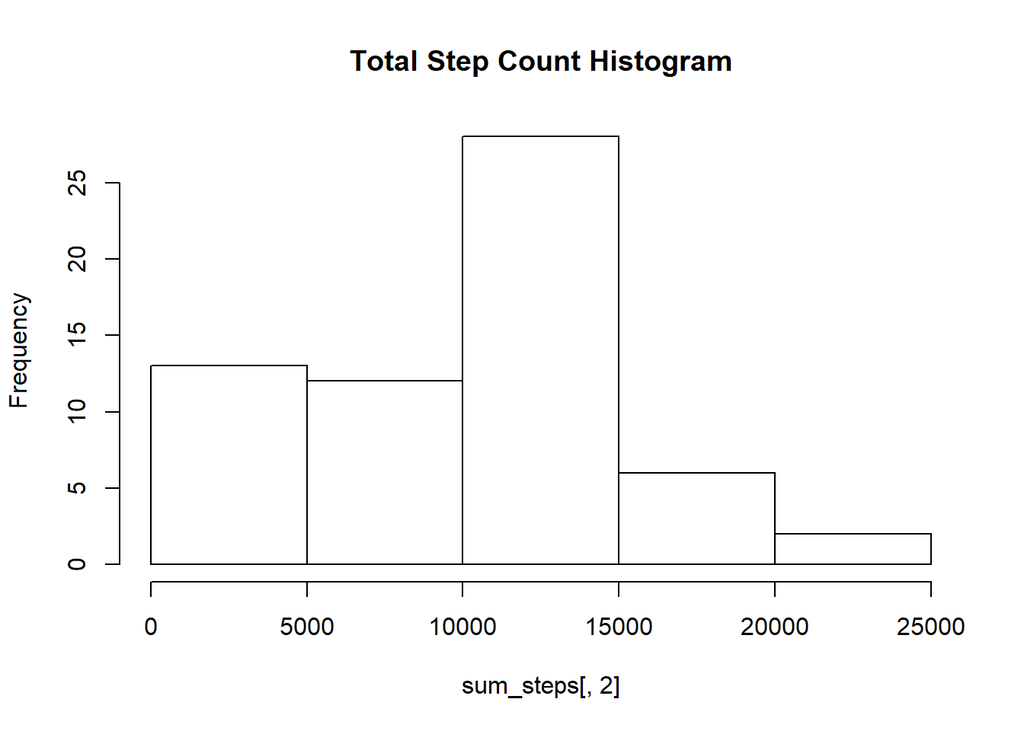

# 2.b Mean and Median

The mean and median are as follows in the summary function

```r
 summary(sum_steps[,2])
```

```
##    Min. 1st Qu.  Median    Mean 3rd Qu.    Max.
##       0    6778   10395    9354   12811   21194
```

# 3. Average Daily Activity Pattern

This was done in two steps

## First one

Calculating the average daily pattern for each 5 minute interval each day through the aggregate function

## Second One

Plotting

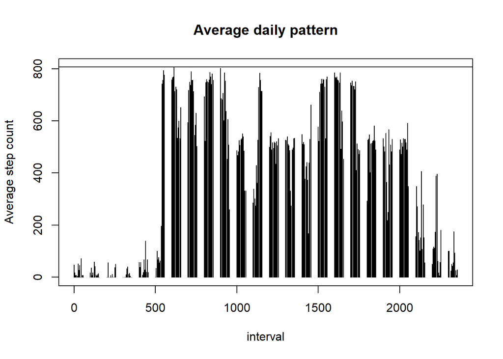

Viewing the Summary of the average daily pattern returns that the max value is 806, equivalent to the interval 615

```r
 summary(mean_steps[,3])
```

```
##    Min. 1st Qu.  Median    Mean 3rd Qu.    Max.    NA's
##    0.00    0.00    0.00   37.38   12.00  806.00    2304
```

# 4.Imputing NAs:

We used a simple manner to do so by replacing the 2304 NAs by the mean of activity$steps, then we created a new NA clean Dataframe called dfnna

[output not shown]

## 4.1 Plotting the new total average number of steps per day and gathering the new mean and median

This was done in the same manner as the original dataset

then the plot:

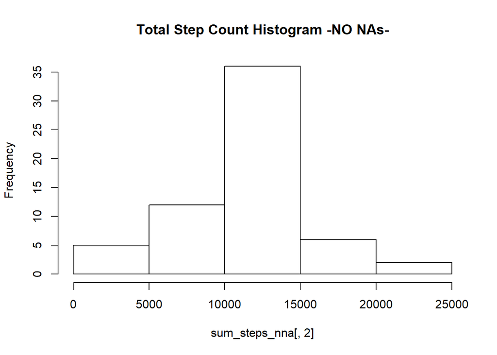

The SUMMARY reports that the median and the mean are now equal

```r
 summary(sum_steps_nna[,2])
```

```
##    Min. 1st Qu.  Median    Mean 3rd Qu.    Max.
##      41    9819   10766   10766   12811   21194
```

# 5. Difference in Average Daily Pattern between Weekdays and Weekends

creating a new factor for weekend and weekday through the weekdays function

```r
 r<-weekdays(as.Date(dfnna$date))
we<-ifelse(r %in% c("samedi", "dimanche"), "weekend", "weekday")
dfnna$weekend_weekday<-we
mean_steps_nna<-aggregate(dfnna[,1], list(dfnna$weekend_weekday,dfnna$interval),
                         mean,
                         na.rm=TRUE)
```

Plotting the Panel Plot:

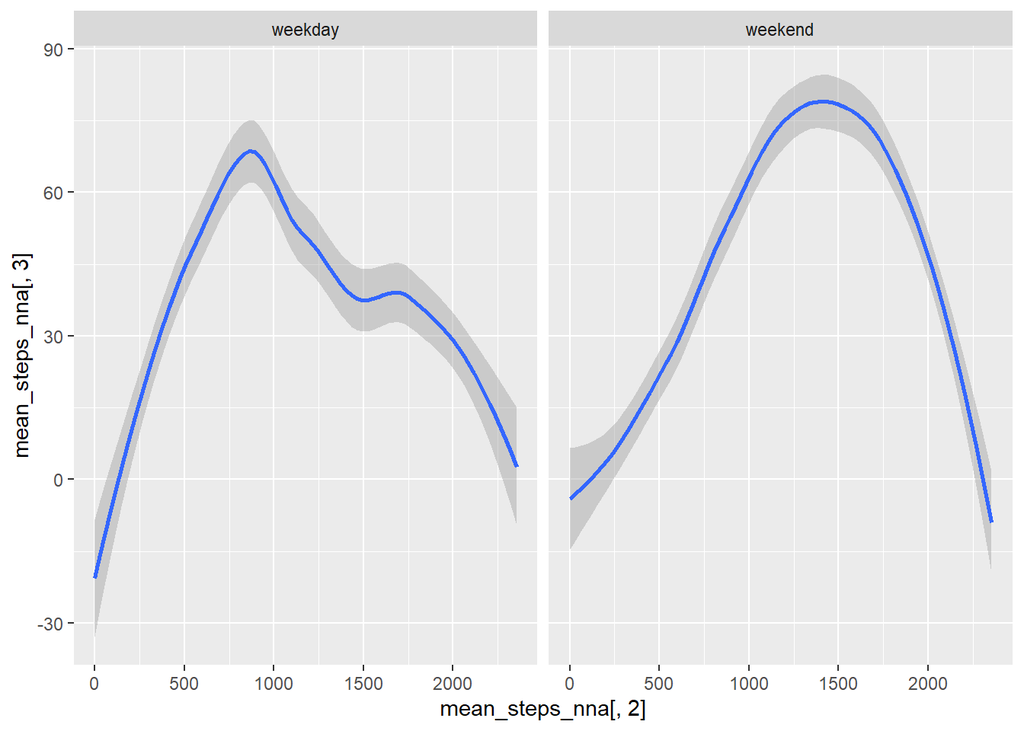

We can observe that average daily pattern is relatively higher in weekends than weekdays, which is interesting

# This Concludes my Report for the Course Project.